# Диагностика линейных моделей

## Диагностика линейных моделей

- Зачем нужен анализ остатков?
- Влиятельные наблюдения
- Типы остатков
- Проверка на влиятельные наблюдения в R
- Проверка условий применимости линейных моделей
  1. Линейность связи
  2. Независимость
  3. Нормальное распределение
  4. Постоянство дисперсии
- Тренинг по анализу остатков

### Вы сможете

- перечислить условия применимости линейной регрессии
- идентифицировать основные нарушения условий применимости линейной регрессии по паттернам на графиках остатков
- написать код на языке R, который позволяет нарисовать диагностические графики остатков для линейной регрессии

## Зачем нужна диагностика модели? Разве тестов было недостаточно?

```r
dat <- read.table('data/orly_owl_Lin_4p_5_flat.txt')
fit <- lm(V1 ~ V2 + V3 + V4 + V5 - 1, data = dat)
coef(summary(fit))
```

```
##    Estimate Std. Error t value Pr(>|t|)
## V2    0.986     0.1280    7.70 1.99e-14
## V3    0.971     0.1266    7.67 2.50e-14
## V4    0.861     0.1196    7.20 8.30e-13
## V5    0.927     0.0833   11.13 4.78e-28
```

Все достоверно? Пишем статью?

## Задание

Постройте график зависимости остатков от предсказанных значений при помощи этого кода

```r
library(car)
residualPlot(fit, pch = ".")
```

## Oh, really?

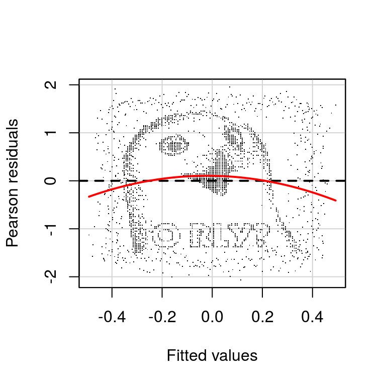

```r
library(car)
residualPlot(fit, pch = ".")
```

http://www4.stat.ncsu.edu/~stefanski/NSF\_Supported/Hidden\_Images/stat\_res\_plots.html

## Анализ остатков линейных моделей

### 1) Проверка на наличие влиятельных наблюдений

### 2) Проверка условий применимости линейных моделей

1. Линейная связь
2. Независимость
3. Нормальное распределение
4. Гомогенность дисерсий
5. Отсутствие коллинеарности предикторов (для можественной регрессии)

## Вспомним пример из прошлой лекции

## Пример: IQ и размеры мозга

Зависит ли уровень интеллекта от размера головного мозга? (Willerman et al. 1991)

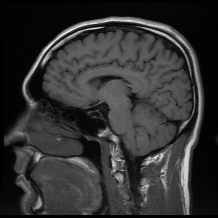

[Scan_03_11](https://flic.kr/p/c45eZ3) by bucaorg(Paul_Burnett) on Flickr

Было исследовано 20 девушек и 20 молодых людей

У каждого индивида измеряли:

- вес
- рост
- размер головного мозга (количество пикселей на изображении ЯМР сканера)
- Уровень интеллекта измеряли с помощью IQ тестов

Пример: Willerman, L., Schultz, R., Rutledge, J. N., and Bigler, E. (1991), "In Vivo Brain Size and Intelligence", Intelligence, 15, p.223–228.  
Данные: ["The Data and Story Library"](http://lib.stat.cmu.edu/DASL)  
Фото: [Scan_03_11](https://flic.kr/p/c45eZ3) by bucaorg (Paul Burnett) on Flickr

## Вспомним, на чем мы остановились

```
##
## Call:
## lm(formula = PIQ ~ MRINACount, data = brain)
##
## Residuals:
##    Min     1Q Median     3Q    Max
##  -39.6  -17.9   -1.6   17.0   42.3
##
## Coefficients:
##               Estimate Std. Error t value Pr(>|t|)
## (Intercept)  1.7437570 42.3923825    0.04    0.967
## MRINACount   0.0001203  0.0000465    2.59    0.014 *
## ---
## Signif. codes:  0 '***' 0.001 '**' 0.01 '*' 0.05 '.' 0.1 ' ' 1
##
## Residual standard error: 21 on 38 degrees of freedom
## Multiple R-squared:  0.15,   Adjusted R-squared:  0.127
## F-statistic: 6.69 on 1 and 38 DF,  p-value: 0.0137
```

## Уравнение и график зависимости

\(PIQ = 1.74376 + 0.00012MRINACount\)

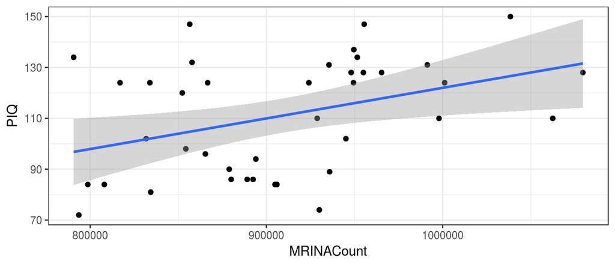

## Анализ остатков

## Какие бывают остатки?

### "Сырые" остатки

\[\varepsilon_i = y_i - \hat{y_i}\]

### Пирсоновские остатки

\[p_i = \frac{\varepsilon_i}{\sqrt{Var(\hat{y_i})}}\] - легко сравнивать (cтандартизованы)

### Стандартизованные (внутренне-стьюдентизированные) остатки

\[s_i = \frac{p_i}{\sqrt{1 - h_{ii}}} = \frac{\varepsilon_i}{\sqrt{Var(\hat{y_i})(1-h_{ii})}}\] - легко сравнивать (стандартизованы), учитывают силу влияния наблюдений

- \(\sqrt{Var(\hat{y_i})}\) — cтандартное отклонение предсказанных значений
- \(h_{ii}\) — "сила воздействия" отдельных наблюдений (leverage, рычаг проекционной матрицы)

## Влиятельные наблюдения

## Влиятельные наблюдения

Влиятельные наблюдения — это наблюдения, которые вносят слишком большой вклад в оценку парметров (коэффициентов) модели.

Из кн. Quinn, Keugh, 2002

## Воздействие точек \(h_{ii}\) (leverage)

показывает силу влияния значений \(x_i\) на ход линии регрессии, то есть на \(\hat{y_i}\)

Из кн. Quinn, Keough, 2002

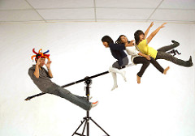

Weighing Machine by neys fadzil on Flickr

## Воздействие точек \(h_{ii}\) (leverage)

Из кн. Quinn, Keough, 2002

- Точки, располагающиеся дальше от \(\bar{x}\), оказывают более сильное влияние на \(\hat{y_i}\)
- Эта величина, в норме, варьирует в промежутке от \(1/n\) до 1
- Если \(h_{ii} > 2(p/n)\), то надо внимательно посмотреть на данное значение (p — число параметров, n — объем выборки)

## Расстояние Кука (Cook's distance)

описывает, как повлияет на модель удаление данного наблюдения

\[D_i = \frac{\sum{(\hat{y_j}-\hat{y}_{j(i)})^2}}{p \cdot MSE} \large( \frac {h_{ii}} {1 - h_{ii}} \large)\]

- \(\hat{y_j}\) - значение предсказанное полной моделью
- \(\hat{y}_{j(i)}\) - значение, предказанное моделью, построенной без учета \(i\)-го значения предиктора
- \(p\) - количество параметров в модели
- \(MSE\) - среднеквадратичная ошибка модели (\(\hat\sigma^2\))
- \(h_{ii}\) — "сила воздействия" отдельных наблюдений (leverage)
- Зависит одновременно от величины остатков и "силы воздействия" наблюдений.
- Условное пороговое значение. Наблюдение является выбросом (outlier), если:
- \(D_i > 1\)
- \(D_i > 4/(N − k − 1)\) (N - объем выборки, k - число предикторов)

## Что делать с наблюдениями-выбросами?

- Удалить?

**Осторожно!** Только очевидные ошибки в наблюдениях можно удалять. Лучше найти причины.

- Трансформировать? Это не всегда поможет.

## Некоторые виды трансформаций

| Трансформация | Формула |
| --- | --- |
| степень -2 | \(1/x^2\) |
| степень -1 | \(1/x\) |
| степень -0.5 | \(1/\sqrt{x}\) |
| степень 0.5 | \(\sqrt{x}\) |
| логарифмирование | \(log(x)\) |

## Данные для анализа остатков

```r
library(ggplot2)
brain_diag <- fortify(brain_model)
head(brain_diag, 2)
```

```
##   PIQ MRINACount   .hat .sigma  .cooksd .fitted .resid .stdresid
## 1 124     816932 0.0664   20.9 0.049838     100  24.02    1.1840
## 2 124    1001121 0.0669   21.3 0.000304     122   1.87    0.0921
```

- `.hat` — "сила воздействия" данного наблюдения (leverage)
- `.cooksd` — расстояние Кука
- `.fitted` — предсказанные значения
- `.resid` — остатки
- `.stdresid` — стандартизованные остатки

## График расстояния Кука

Проверяем наличие влиятельных наблюдений в `brain_model`.

Значения на графике расстояния Кука приведены в том же порядке, что и в исходных данных.

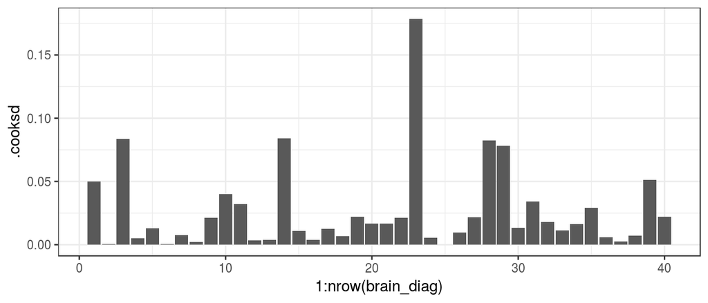

```r
# График расстояния Кука
ggplot(brain_diag, aes(x = 1:nrow(brain_diag), y = .cooksd)) +
  geom_bar(stat = "identity")
```

- Есть одно влиятельное наблюдение, которое нужно проверить, но сила его влияния невелика (расстояние Кука < 1, и только одно наблюдение больше 4/(n-k-1) = 0.11)

## График остатков от предсказанных значений

Большую часть того, что нужно знать про остатки вы увидите на этом графике. А сейчас давайте научимся читать такой график.

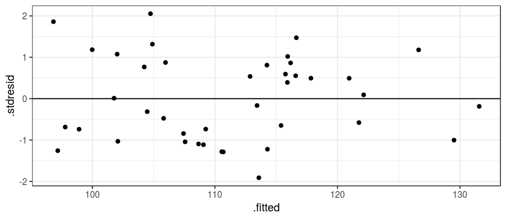

```r
gg_resid <- ggplot(data = brain_diag, aes(x = .fitted, y = .stdresid)) +
  geom_point() +
  geom_hline(yintercept = 0)
gg_resid
```

## 1. Линейность связи

## Нелинейность связи лучше заметна на графиках остатков

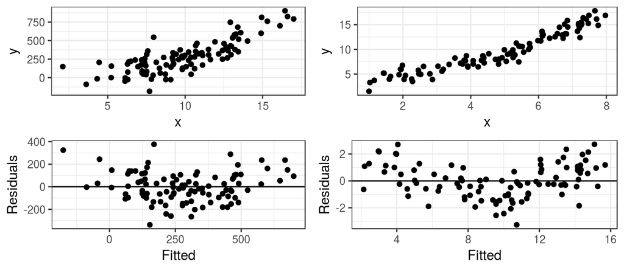

### Проверка на линейность связи

- График зависимости \(Y\) от \(x\) (и от других переменных, не включенных в модель)
- График остатков от предсказанных значений

## Что делать, если связь нелинейна?

- Добавить неучтенные переменные или взаимодействия
- Применить линеаризующее преобразование (Осторожно!)
- Применить обобщенную линейную модель с другой функцией связи (GLM)
- Построить аддитивную модель (GAM), если достаточно наблюдений по \(x\)
- Построить нелинейную модель, если известна форма зависимости

## Пример линеаризующего преобразования

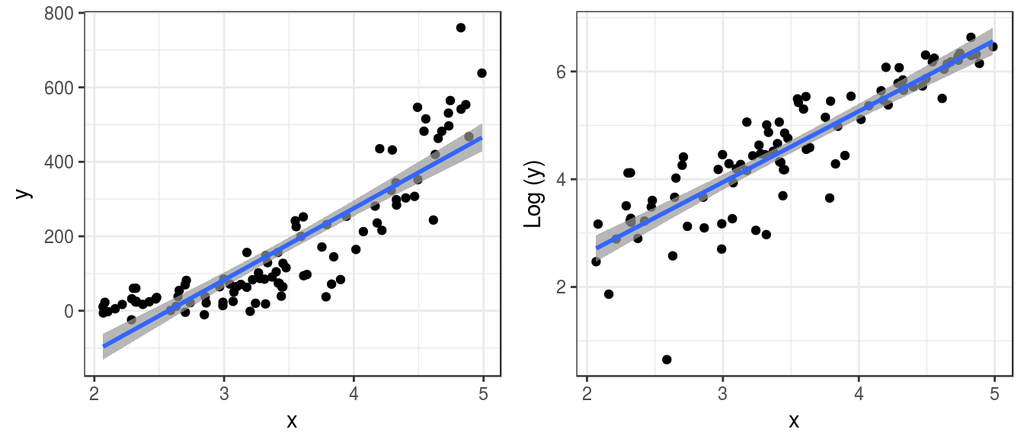

**Осторожно!** Вы рискуете изучить не то, что хотели.  
При прочих равных, лучше преобразовывать предиктор, а не отклик.

## 2. Независимость

## Каждое значение \(Y_i\) должно быть независимо от любого другого \(Y_j\)

Это нужно контролировать на этапе планирования сбора материала

- Наиболее частые источники зависимостей:
  - псевдоповторности (повторно измеренные объекты)
  - неучтенные переменные
  - временные автокорреляции (если данные - временной ряд)
  - пространственные автокорреляции (если пробы взяты в разных местах)
  - и т.п.

## Диагностика нарушений независимости

Взаимозависимости можно заметить на графиках остатков

- остатки vs. предсказанные значения
- остатки vs. переменные в модели
- остатки vs. переменные не в модели

## Нарушение условия независимости: Неучтенная переменная

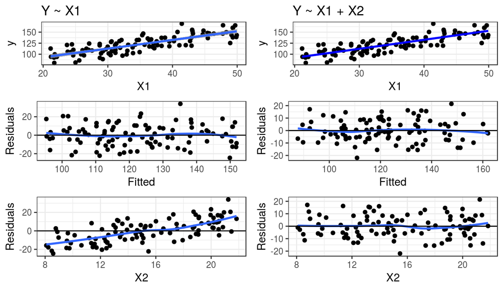

- Слева: Если в модели не учтена переменная \(X2\), внешне все нормально, но величина остатков зависит от \(X2\)
- Справа: Если \(X2\) учесть, то зависимость остатков от \(X2\) исчезает

## Нарушение условия независимости: Автокорреляция

В данном случае, наблюдения — это временной ряд.

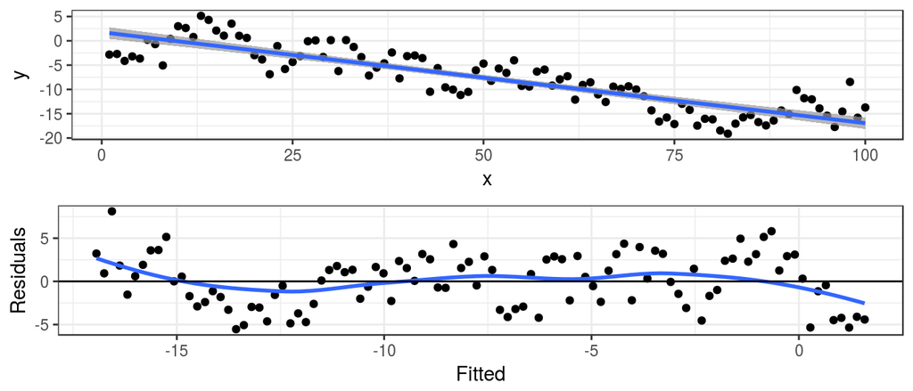

На графиках остатков четко видно, что остатки не являются независимыми.

## Проверка на автокорреляцию

Проверка на автокорреляцию нужна если данные это временной ряд, или если известны координаты или время сбора проб.

Способы проверки временной автокорреляции (годятся, если наблюдения в ряду расположены через равные интервалы):

- График автокорреляционной функции остатков (ACF-plot) покажет корреляции с разными лагами.
- Критерий Дарбина-Уотсона (значимость автокорреляции 1-го порядка).

Для проверки пространственных автокорреляций

- вариограмма
- I Морана (Moran's I)

## Что делать, если у вас нарушено условие независимости значений?

Выбор зависит от обстоятельств. Вот несколько возможных вариантов.

- псевдоповторности
  - избавляемся от псевдоповторностей, вычислив среднее
  - подбираем модель со случайным фактором
- неучтенные переменные
  - включаем в модель (если возможно)
- временные автокорреляции
  - моделируем автокорреляцию
  - подбираем модель со случайным фактором
- пространственные автокорреляции
  - моделируем пространственную автокорреляцию
  - делим на пространственные блоки и подбираем модель со случайным фактором (= random effects model, mixed model)

## Проверка условия независимости

### Графики зависимости остатков от предикторов в модели

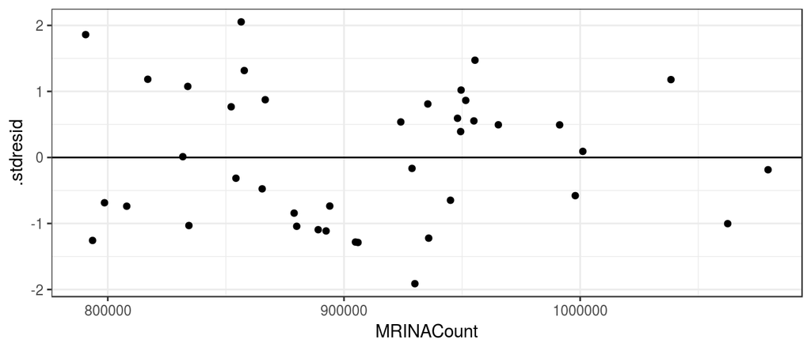

```r
# Полный код
ggplot(data = brain_diag, aes(x = MRINACount, y = .stdresid)) +
  geom_point() +
  geom_hline(yintercept = 0)
```

```r
# То же самое с использованием ранее созданного gg_resid
gg_resid + aes(x =  MRINACount)
```

### Графики зависимости остатков от предикторов не в модели

В данном случае их нет

## 3. Нормальное распределение

## 3. Нормальное распределение \(Y\) (для каждого уровня значений \(X\))

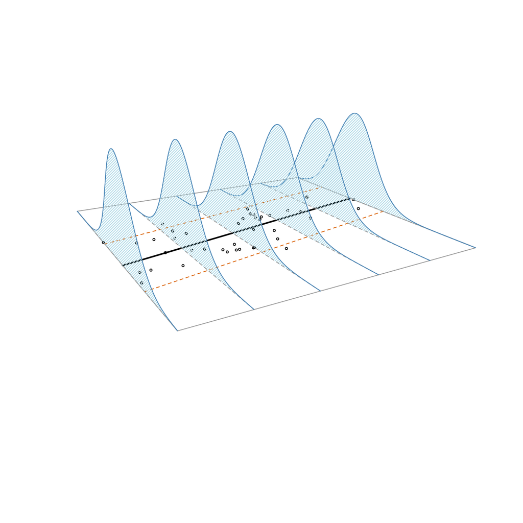

## Проверка на нормальность

Это условие невозможно проверить "влоб", т.к. обычно каждому \(X\) сообветствует лишь небольшое число \(Y\)

Если \(Y\) это нормально распределенная случайная величина

\[Y_i \in N(\mu_{y_i}, \sigma^2)\]

и мы моделируем ее как

\[Y_i \sim b_0 + b_1x_{1i} + \cdots + \varepsilon_i\]

то остатки от этой модели — тоже нормально распределенная случайная величина

\[\varepsilon_i \in N(\mu_{y_i}, \sigma^2)\]

Т.е. выполнение этого условия можно оценить по поведению случайной части модели.

## Проверка нормальности распределения остатков

Есть формальные тесты, но:

- у формальных тестов тоже есть свои условия применимости
- при больших выборках формальные тесты покажут, что значимы даже небольшие отклонения от нормального распределения
- тесты, которые используются в линейной регрессии, устойчивы к небольшим отклонениям от нормального распределения

Лучший способ проверки — квантильный график остатков.

## Квантильный график остатков

По оси Х — квантили теоретического распределения, по оси Y — квантили остатков модели.

Если точки — это реализации случайной величины из \(N(0, \sigma^2)\), то они должны лечь вдоль прямой \(Y = X\). Если это стьюдентизированные остатки — то используются квантили t-распределения

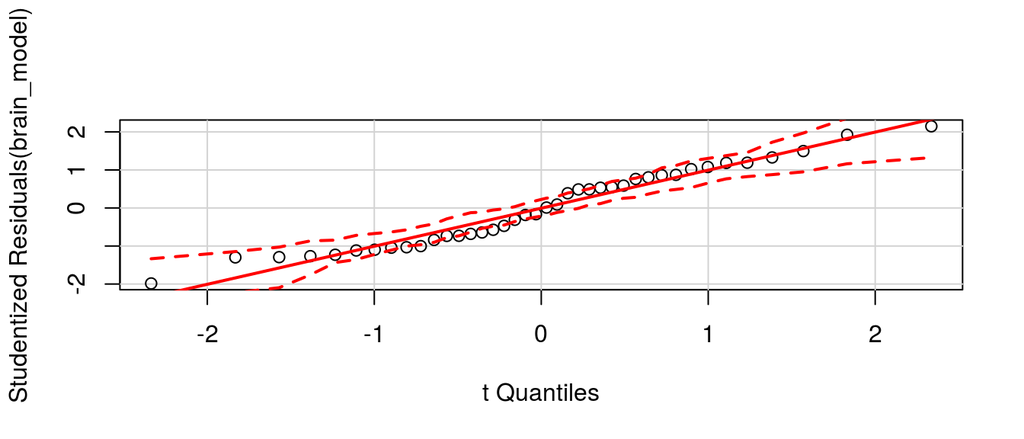

```r
# library(car)
qqPlot(brain_model) # из пакета car
```

## Что делать, если остатки распределены не нормально?

Зависит от причины

- Нелинейная связь?
  - Построить аддитивную модель (если достаточно наблюдений по \(x\))
  - Построить нелинейную модель (если известна форма зависимости)
- Неучтенные переменные?
  - добавляем в модель
- Зависимая переменная распределена по-другому?
  - трансформируем данные (неудобно)
  - подбираем модель с другим распределением остатков (обобщенную линейную модель)

## 4. Постоянство дисперсии

## 4. Постоянство дисперсии (= гомогенность дисперсии, гомоскедастичность)

Это самое важное условие, поскольку многие тесты чувствительны к гетероскедастичности.

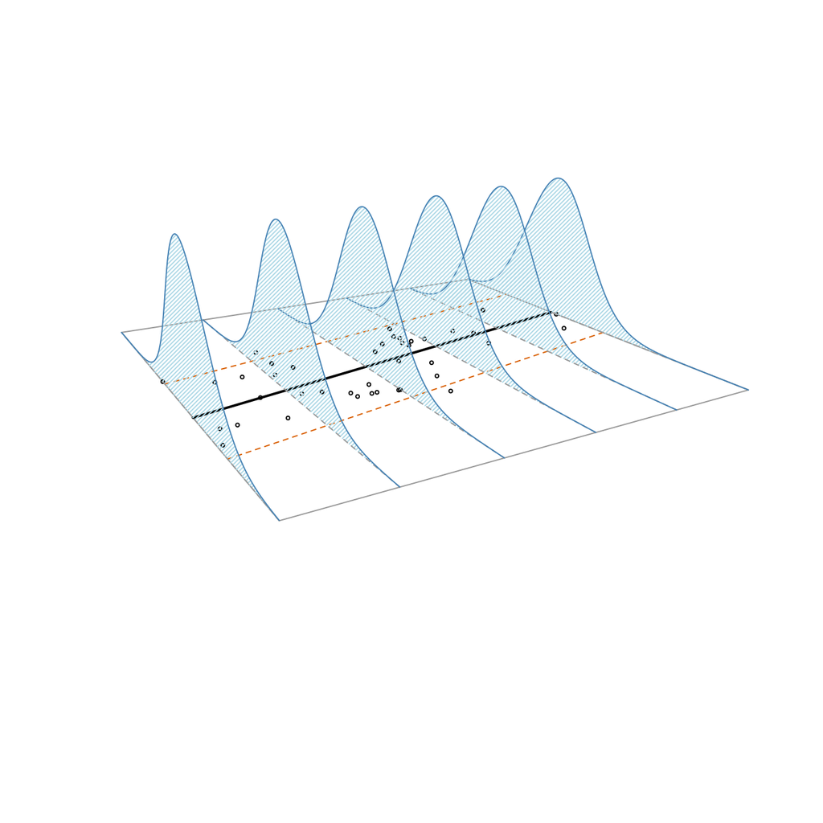

## Проверка гомогенности дисперсий

Есть формальные тесты (тест Бройша-Пагана, тест Кокрана), но:

- у формальных тестов тоже есть свои условия применимости, и многие сами неустойчивы к гетероскедастичности
- при больших выборках формальные тесты покажут, что значима даже небольшая гетероскедастичность

Лучший способ проверки на гомогенность дисперсий — график остатков.

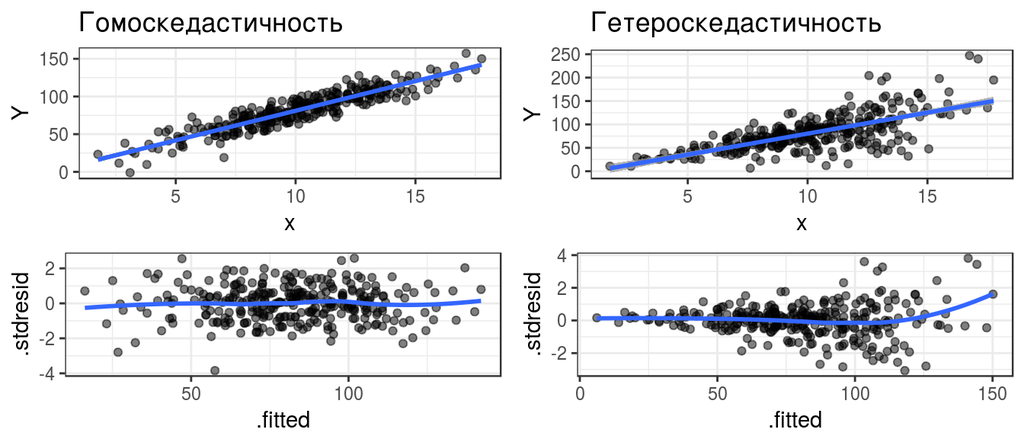

## Проверка на гетероскедастичность

Этот график у нас уже есть

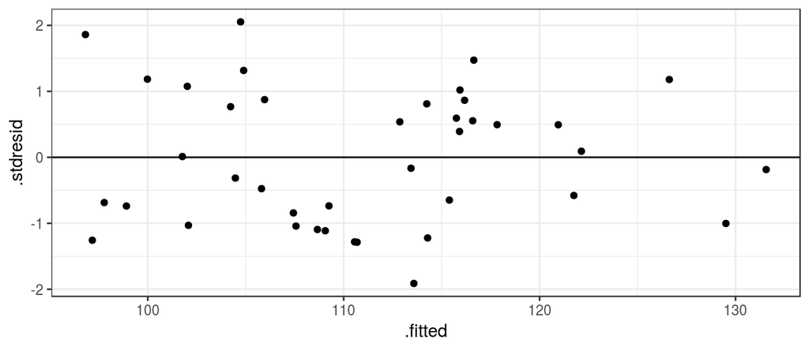

```r
gg_resid
```

- Гетерогенность дисперсий не выражена.

## Что делать если вы столкнулись с гетероскедастичностью?

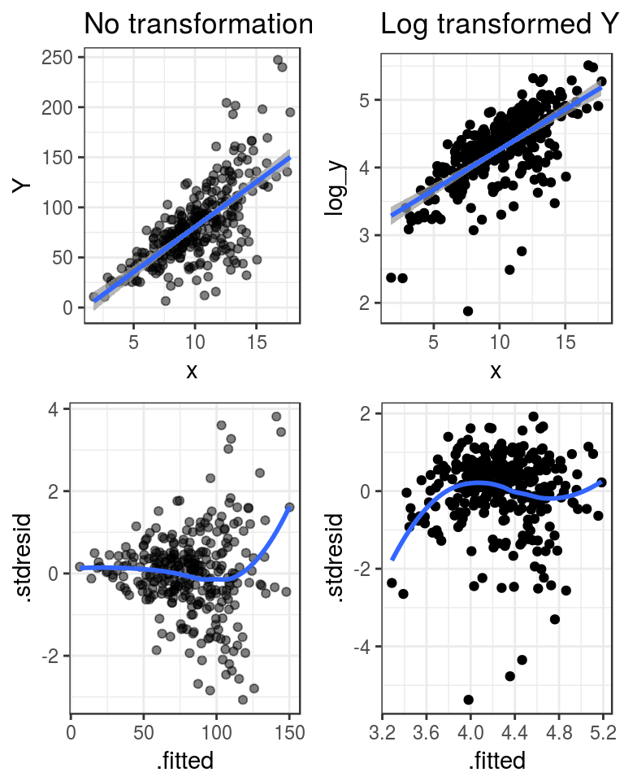

Трансформация может помочь…

## Возможные причины гетероскедостичности

Даже если трансформация может помочь, лучше поискать причину гетерогенности дисперсий

- Неучтенные переменные
  - добавляем в модель
- Зависимая переменная распределена по-другому
  - трансформируем данные (неудобно)
  - подбираем модель с другим распределением остатков (обобщенную линейную модель)
- Моделируем гетерогенность дисперсии.

## Тренинг по анализу остатков

## Некоторые частые паттерны на графиках остатков

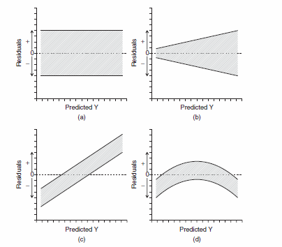

Из кн. Logan, 2010, стр. 174

- Рис. a — Условия применимости соблюдаются, модель хорошая
- Рис. b — Клиновидный паттерн. Есть гетероскедастичность. Модель плохая
- Рис. c — Остатки рассеяны равномерно, но нужны дополнительные предикторы
- Рис. d — Нелинейный паттерн. Линейная модель использована некорректно

## Задание

Выполните три блока кода

Какие нарушения условий применимости линейных моделей здесь наблюдаются?

Вам понадобятся

1. График расстояния Кука
2. График остатков от предсказанных значений
3. Графики остатков от предикторов в модели и не в модели
4. Квантильный график остатков

## Задание, блок 1

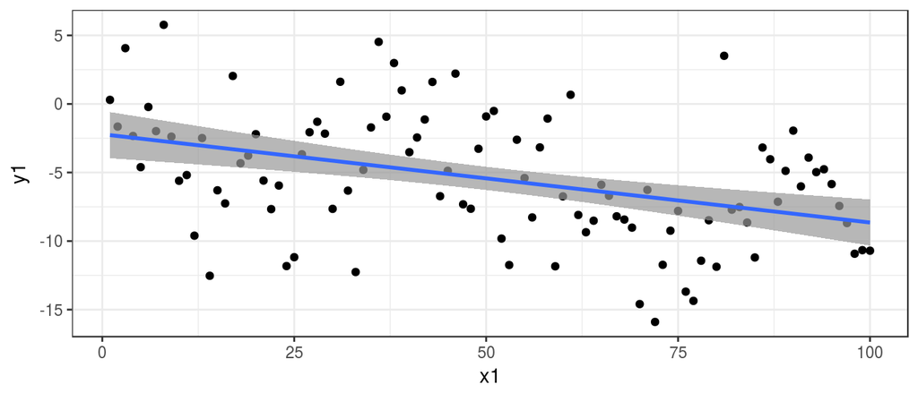

```r
set.seed(90829)
x1 <- seq(1, 100, 1)
y1 <-  diffinv(rnorm(99))  + rnorm(100, 0.2, 4)
dat1 = data.frame(x1, y1)
ggplot(dat1, aes(x = x1, y =  y1)) + geom_point()+
  geom_smooth(method="lm", alpha = 0.7)
```

## Решение, блок 1

### Графики

- Выбросов нет, зависимость нелинейна
- Выраженных отклонений от нормального распределения нет

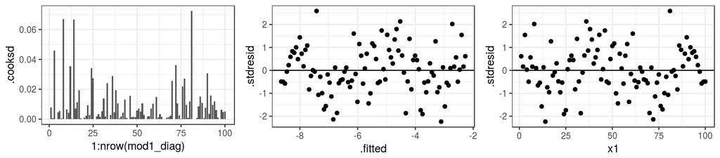

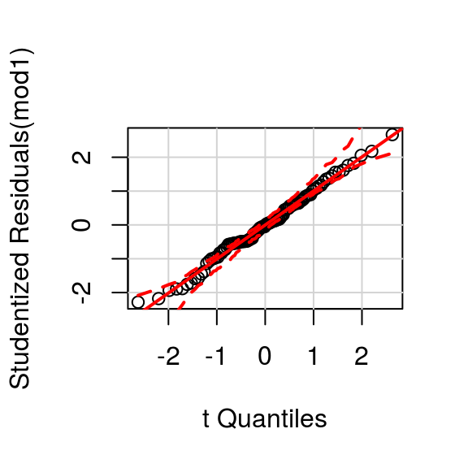

## Решение, блок 1

```r
mod1 <- lm(y1 ~ x1, data = dat1)

# Данные для графиков остатков
mod1_diag <- fortify(mod1)

# 1) График расстояния Кука
ggplot(mod1_diag, aes(x = 1:nrow(mod1_diag), y = .cooksd)) +
  geom_bar(stat = "identity")

# 2) График остатков от предсказанных значений
gg_resid <- ggplot(data = mod1_diag, aes(x = .fitted, y = .stdresid)) +
  geom_point() + geom_hline(yintercept = 0)
gg_resid

# 3) Графики остатков от предикторов в модели и не в модели
gg_resid + aes(x = x1)

# 4) Квантильный график остатков
qqPlot(mod1)
```

## Задание, блок 2

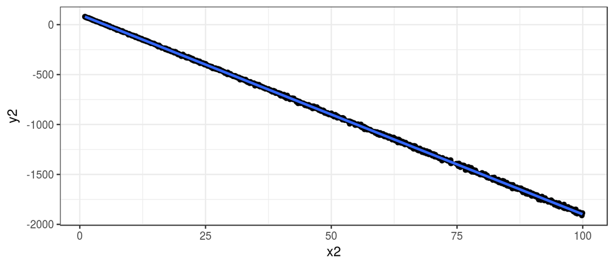

```r
  set.seed(7657674)
  x2 <- runif(1000, 1, 100)
  b_0 <- 100;  b_1 <- -20
  h <- function(x) x^0.5
  eps <- rnorm(1000, 0, h(x2))
  y2 <- b_0 + b_1 * x2 + eps
  dat2 <- data.frame(x2, y2)
  ggplot(dat2, aes(x = x2, y = y2)) + geom_point() + geom_smooth(method = "lm")
```

## Решение, блок 2

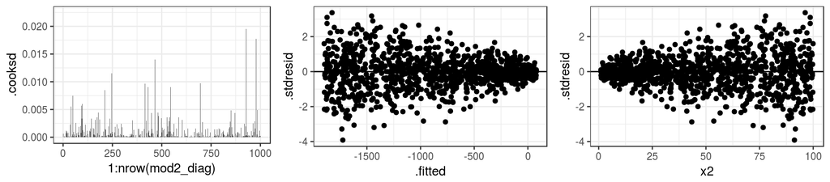

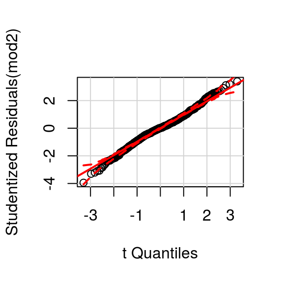

## Решение, блок 2

```r
mod2 <- lm(y2 ~ x2, data = dat2)

# Данные для графиков остатков
mod2_diag <- fortify(mod2)

# 1) График расстояния Кука
ggplot(mod2_diag, aes(x = 1:nrow(mod2_diag), y = .cooksd)) +
  geom_bar(stat = "identity")

# 2) График остатков от предсказанных значений
gg_resid <- ggplot(data = mod2_diag, aes(x = .fitted, y = .stdresid)) +
  geom_point() + geom_hline(yintercept = 0)
gg_resid

# 3) Графики остатков от предикторов в модели и не в модели
gg_resid + aes(x = x2)

# 4) Квантильный график остатков
qqPlot(mod2)
```

## Задание, блок 3

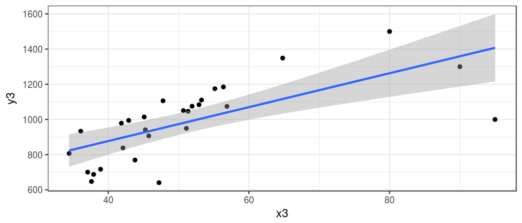

```r
set.seed(9283)
x3 <- rnorm(25, 50, 10)
b_0 <- 20; b_1 <- 20; eps <- rnorm(50, 0, 100)
y3 <- b_0 + b_1*x3 + eps
y3[100] <- 1000; x3[100] <- 95; y3[99] <- 1300; x3[99] <- 90; y3[98] <- 1500; x3[98] <- 80
dat3 <- data.frame(x3, y3)
ggplot(dat3, aes(x=x3, y=y3)) + geom_point() + geom_smooth(method="lm")
```

## Решение, блок 3

- 100-е наблюдение сильно влияет на ход регрессии
- Зависимость нелинейна

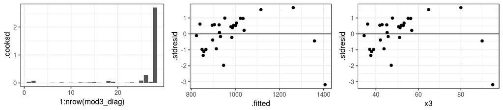

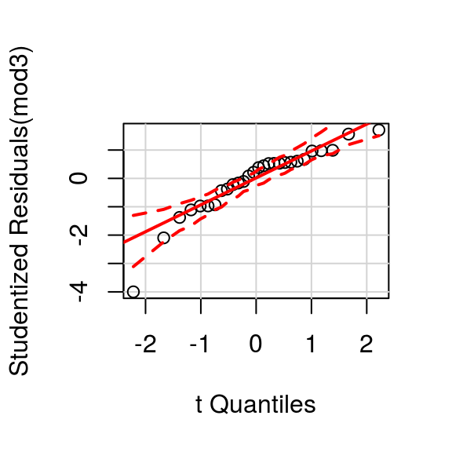

## Решение, блок 3

```r
mod3 <- lm(y3 ~ x3, data = dat3)

# Данные для графиков остатков
mod3_diag <- fortify(mod3)

# 1) График расстояния Кука
ggplot(mod3_diag, aes(x = 1:nrow(mod3_diag), y = .cooksd)) +
  geom_bar(stat = "identity")

# 2) График остатков от предсказанных значений
gg_resid <- ggplot(data = mod3_diag, aes(x = .fitted, y = .stdresid)) +
  geom_point() + geom_hline(yintercept = 0)
gg_resid

# 3) Графики остатков от предикторов в модели и не в модели
gg_resid + aes(x = x3)

# 4) Квантильный график остатков
qqPlot(mod3)
```

## Take-home messages

- У линейных моделей есть условия применимости
- Если условия применимости нарушены, то такой моделью нельзя пользоваться, даже если анализ показывает достоверную зависимость
- Анализ остатков дает разностороннюю информацию о валидности моделей

## Что почитать

- Кабаков Р.И. R в действии. Анализ и визуализация данных на языке R. М.: ДМК Пресс, 2014
- Diez, D.M., Barr, C.D. and Çetinkaya-Rundel, M., 2015. OpenIntro Statistics. OpenIntro.
- Zuur, A., Ieno, E.N. and Smith, G.M., 2007. Analyzing ecological data. Springer Science & Business Media.
- Quinn G.P., Keough M.J. 2002. Experimental design and data analysis for biologists
- Logan M. 2010. Biostatistical Design and Analysis Using R. A Practical Guide